# Semiconductor Manufacturing

## Project Description

[Source](https://www.kaggle.com/saurabhbagchi/fmst-semiconductor-manufacturing-project)

A complex modern semiconductor manufacturing process is normally under constant surveillance via the monitoring of signals/variables collected from sensors and or process measurement points. However, not all of these signals are equally valuable in a specific monitoring system. The measured signals contain a combination of useful information, irrelevant information as well as noise. Engineers typically have a much larger number of signals than are actually required. If we consider each type of signal as a feature, then feature selection may be applied to identify the most relevant signals. The Process Engineers may then use these signals to determine key factors contributing to yield excursions downstream in the process. This will enable an increase in process throughput, decreased time to learning, and reduce per-unit production costs. These signals can be used as features to predict the yield type. And by analyzing and trying out different combinations of features, essential signals that are impacting the yield type can be identified.

## Context

Manufacturing process feature selection and categorization

## Content

Abstract: Data from a semi-conductor manufacturing process

- Data Set Characteristics: Multivariate
- Number of Instances: 1567
- Area: Computer
- Attribute Characteristics: Real
- Number of Attributes: 591
- Date Donated: 2008-11-19
- Associated Tasks: Classification, Causal-Discovery
- Missing Values? Yes

A complex modern semi-conductor manufacturing process is normally under consistent surveillance via the monitoring of signals/variables collected from sensors and or process measurement points. However, not all of these signals are equally valuable in a specific monitoring system. The measured signals contain a combination of useful information, irrelevant information as well as noise. It is often the case that useful information is buried in the latter two. Engineers typically have a much larger number of signals than are actually required. If we consider each type of signal as a feature, then feature selection may be applied to identify the most relevant signals. The Process Engineers may then use these signals to determine key factors contributing to yield excursions downstream in the process. This will enable an increase in process throughput, decreased time to learning and reduce the per unit production costs.

To enhance current business improvement techniques the application of feature selection as an intelligent systems technique is being investigated.

The dataset presented in this case represents a selection of such features where each example represents a single production entity with associated measured features and the labels represent a simple pass/fail yield for in house line testing, figure 2, and associated date time stamp. Where .1 corresponds to a pass and 1 corresponds to a fail and the data time stamp is for that specific test point.

[Source: UCI SECOM Dataset via Kaggle](https://www.kaggle.com/paresh2047/uci-semcom)

## Acknowledgements

**Dataset Authors**: Michael McCann, Adrian Johnston

# General Setup

## Importing the Libraries

```python
import numpy as np
import matplotlib.pyplot as plt
import pandas as pd
import tensorflow as tf
import seaborn as sns
```

## Importing the Dataset

```python
dataset = pd.read_csv('SemiconductorManufacturingProcessDataset.csv')
```

## Showing the Dataset in a Table

```python
pd.DataFrame(dataset)
#dataset
```

|  | Time | Sensor 1 | Sensor 2 | Sensor 3 | Sensor 4 | Sensor 5 | Sensor 6 | Sensor 7 | Sensor 8 | Sensor 9 | ... | Sensor 429 | Sensor 430 | Sensor 431 | Sensor 432 | Sensor 433 | Sensor 434 | Sensor 435 | Sensor 436 | Sensor 437 | Pass/Fail |
| --- | --- | --- | --- | --- | --- | --- | --- | --- | --- | --- | --- | --- | --- | --- | --- | --- | --- | --- | --- | --- | --- |
| 0 | 7/19/2008 11:55 | 3030.93 | 2564.00 | 2187.7333 | 1411.1265 | 1.3602 | 97.6133 | 0.1242 | 1.5005 | 0.0162 | ... | 14.9509 | 0.5005 | 0.0118 | 0.0035 | 2.3630 | NaN | NaN | NaN | NaN | Pass |
| 1 | 7/19/2008 12:32 | 3095.78 | 2465.14 | 2230.4222 | 1463.6606 | 0.8294 | 102.3433 | 0.1247 | 1.4966 | -0.0005 | ... | 10.9003 | 0.5019 | 0.0223 | 0.0055 | 4.4447 | 0.0096 | 0.0201 | 0.0060 | 208.2045 | Pass |
| 2 | 7/19/2008 13:17 | 2932.61 | 2559.94 | 2186.4111 | 1698.0172 | 1.5102 | 95.4878 | 0.1241 | 1.4436 | 0.0041 | ... | 9.2721 | 0.4958 | 0.0157 | 0.0039 | 3.1745 | 0.0584 | 0.0484 | 0.0148 | 82.8602 | Fail |
| 3 | 7/19/2008 14:43 | 2988.72 | 2479.90 | 2199.0333 | 909.7926 | 1.3204 | 104.2367 | 0.1217 | 1.4882 | -0.0124 | ... | 8.5831 | 0.4990 | 0.0103 | 0.0025 | 2.0544 | 0.0202 | 0.0149 | 0.0044 | 73.8432 | Pass |
| 4 | 7/19/2008 15:22 | 3032.24 | 2502.87 | 2233.3667 | 1326.5200 | 1.5334 | 100.3967 | 0.1235 | 1.5031 | -0.0031 | ... | 10.9698 | 0.4800 | 0.4766 | 0.1045 | 99.3032 | 0.0202 | 0.0149 | 0.0044 | 73.8432 | Pass |
| ... | ... | ... | ... | ... | ... | ... | ... | ... | ... | ... | ... | ... | ... | ... | ... | ... | ... | ... | ... | ... | ... |
| 1562 | 10/16/2008 15:13 | 2899.41 | 2464.36 | 2179.7333 | 3085.3781 | 1.4843 | 82.2467 | 0.1248 | 1.3424 | -0.0045 | ... | 11.7256 | 0.4988 | 0.0143 | 0.0039 | 2.8669 | 0.0068 | 0.0138 | 0.0047 | 203.1720 | Pass |
| 1563 | 10/16/2008 20:49 | 3052.31 | 2522.55 | 2198.5667 | 1124.6595 | 0.8763 | 98.4689 | 0.1205 | 1.4333 | -0.0061 | ... | 17.8379 | 0.4975 | 0.0131 | 0.0036 | 2.6238 | 0.0068 | 0.0138 | 0.0047 | 203.1720 | Pass |
| 1564 | 10/17/2008 5:26 | 2978.81 | 2379.78 | 2206.3000 | 1110.4967 | 0.8236 | 99.4122 | 0.1208 | NaN | NaN | ... | 17.7267 | 0.4987 | 0.0153 | 0.0041 | 3.0590 | 0.0197 | 0.0086 | 0.0025 | 43.5231 | Pass |
| 1565 | 10/17/2008 6:01 | 2894.92 | 2532.01 | 2177.0333 | 1183.7287 | 1.5726 | 98.7978 | 0.1213 | 1.4622 | -0.0072 | ... | 19.2104 | 0.5004 | 0.0178 | 0.0038 | 3.5662 | 0.0262 | 0.0245 | 0.0075 | 93.4941 | Pass |
| 1566 | 10/17/2008 6:07 | 2944.92 | 2450.76 | 2195.4444 | 2914.1792 | 1.5978 | 85.1011 | 0.1235 | NaN | NaN | ... | 22.9183 | 0.4987 | 0.0181 | 0.0040 | 3.6275 | 0.0117 | 0.0162 | 0.0045 | 137.7844 | Pass |

1567 rows × 439 columns

# Data Exploration

## A Quick Review of the Data

```python
dataset.info()
```

```
<class 'pandas.core.frame.DataFrame'>
RangeIndex: 1567 entries, 0 to 1566
Columns: 439 entries, Time to Pass/Fail
dtypes: float64(437), object(2)
memory usage: 5.2+ MB
```

## Feature Set: Center, Spread, and Range

```python
dataset.describe()
```

|  | Sensor 1 | Sensor 2 | Sensor 3 | Sensor 4 | Sensor 5 | Sensor 6 | Sensor 7 | Sensor 8 | Sensor 9 | Sensor 10 | ... | Sensor 428 | Sensor 429 | Sensor 430 | Sensor 431 | Sensor 432 | Sensor 433 | Sensor 434 | Sensor 435 | Sensor 436 | Sensor 437 |
| --- | --- | --- | --- | --- | --- | --- | --- | --- | --- | --- | --- | --- | --- | --- | --- | --- | --- | --- | --- | --- | --- |
| count | 1561.000000 | 1560.000000 | 1553.000000 | 1553.000000 | 1553.000000 | 1553.000000 | 1558.000000 | 1565.000000 | 1565.000000 | 1565.000000 | ... | 1567.000000 | 1567.000000 | 1566.000000 | 1566.000000 | 1566.000000 | 1566.000000 | 1566.000000 | 1566.000000 | 1566.000000 | 1566.000000 |
| mean | 3014.452896 | 2495.850231 | 2200.547318 | 1396.376627 | 4.197013 | 101.112908 | 0.121822 | 1.462862 | -0.000841 | 0.000146 | ... | 5.563747 | 16.642363 | 0.500096 | 0.015318 | 0.003847 | 3.067826 | 0.021458 | 0.016475 | 0.005283 | 99.670066 |
| std | 73.621787 | 80.407705 | 29.513152 | 441.691640 | 56.355540 | 6.237214 | 0.008961 | 0.073897 | 0.015116 | 0.009302 | ... | 16.921369 | 12.485267 | 0.003404 | 0.017180 | 0.003720 | 3.578033 | 0.012358 | 0.008808 | 0.002867 | 93.891919 |
| min | 2743.240000 | 2158.750000 | 2060.660000 | 0.000000 | 0.681500 | 82.131100 | 0.000000 | 1.191000 | -0.053400 | -0.034900 | ... | 0.663600 | 4.582000 | 0.477800 | 0.006000 | 0.001700 | 1.197500 | -0.016900 | 0.003200 | 0.001000 | 0.000000 |
| 25% | 2966.260000 | 2452.247500 | 2181.044400 | 1081.875800 | 1.017700 | 97.920000 | 0.121100 | 1.411200 | -0.010800 | -0.005600 | ... | 1.408450 | 11.501550 | 0.497900 | 0.011600 | 0.003100 | 2.306500 | 0.013425 | 0.010600 | 0.003300 | 44.368600 |
| 50% | 3011.490000 | 2499.405000 | 2201.066700 | 1285.214400 | 1.316800 | 101.512200 | 0.122400 | 1.461600 | -0.001300 | 0.000400 | ... | 1.624500 | 13.817900 | 0.500200 | 0.013800 | 0.003600 | 2.757650 | 0.020500 | 0.014800 | 0.004600 | 71.900500 |
| 75% | 3056.650000 | 2538.822500 | 2218.055500 | 1591.223500 | 1.525700 | 104.586700 | 0.123800 | 1.516900 | 0.008400 | 0.005900 | ... | 1.902000 | 17.080900 | 0.502375 | 0.016500 | 0.004100 | 3.295175 | 0.027600 | 0.020300 | 0.006400 | 114.749700 |
| max | 3356.350000 | 2846.440000 | 2315.266700 | 3715.041700 | 1114.536600 | 129.252200 | 0.128600 | 1.656400 | 0.074900 | 0.053000 | ... | 90.423500 | 96.960100 | 0.509800 | 0.476600 | 0.104500 | 99.303200 | 0.102800 | 0.079900 | 0.028600 | 737.304800 |

8 rows × 437 columns

## Plotting the Raw Data

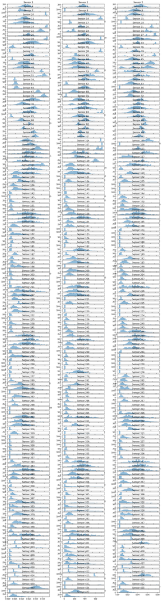

```python
import warnings
warnings.filterwarnings('ignore')
with warnings.catch_warnings():      #Catch warnings in code section
    warnings.simplefilter("ignore")
    plt.subplots(figsize=(15,60));
    ax = plt.gca();
    dataset.hist(bins=30, figsize=(10,10), grid=False, layout=(146,3), sharex=False, ax=ax, alpha=0.5);
    plt.tight_layout();
```

## General Corelations

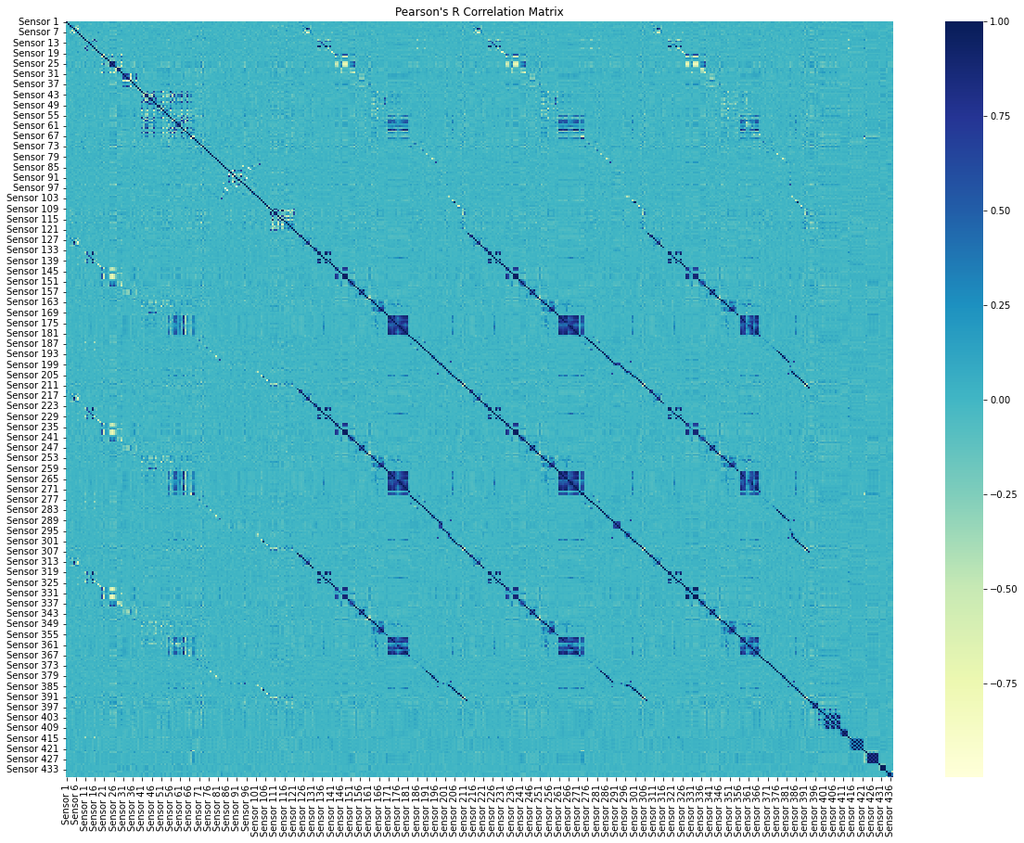

```python
corr_mat = dataset.corr(method='pearson');
mask = np.triu(np.ones_like(corr_mat, dtype=bool));
plt.figure(dpi=1000);
plt.subplots(figsize=(20,15));
plt.title("Pearson's R Correlation Matrix");
sns.heatmap(corr_mat, annot=False, lw=0, linecolor='white', cmap='YlGnBu');
print();
```

# Data Preprocessing

## Seperate The Input and Output

Here, we put the independent variables in X and the dependent variable in y.

```python
X = dataset.iloc[:, 1:438].values
y = dataset.iloc[:, -1].values
```

## Showing the Input Data in a Table format

```python
pd.DataFrame(X)
```

|  | 0 | 1 | 2 | 3 | 4 | 5 | 6 | 7 | 8 | 9 | ... | 427 | 428 | 429 | 430 | 431 | 432 | 433 | 434 | 435 | 436 |
| --- | --- | --- | --- | --- | --- | --- | --- | --- | --- | --- | --- | --- | --- | --- | --- | --- | --- | --- | --- | --- | --- |
| 0 | 3030.93 | 2564.00 | 2187.7333 | 1411.1265 | 1.3602 | 97.6133 | 0.1242 | 1.5005 | 0.0162 | -0.0034 | ... | 1.6765 | 14.9509 | 0.5005 | 0.0118 | 0.0035 | 2.3630 | NaN | NaN | NaN | NaN |
| 1 | 3095.78 | 2465.14 | 2230.4222 | 1463.6606 | 0.8294 | 102.3433 | 0.1247 | 1.4966 | -0.0005 | -0.0148 | ... | 1.1065 | 10.9003 | 0.5019 | 0.0223 | 0.0055 | 4.4447 | 0.0096 | 0.0201 | 0.0060 | 208.2045 |
| 2 | 2932.61 | 2559.94 | 2186.4111 | 1698.0172 | 1.5102 | 95.4878 | 0.1241 | 1.4436 | 0.0041 | 0.0013 | ... | 2.0952 | 9.2721 | 0.4958 | 0.0157 | 0.0039 | 3.1745 | 0.0584 | 0.0484 | 0.0148 | 82.8602 |
| 3 | 2988.72 | 2479.90 | 2199.0333 | 909.7926 | 1.3204 | 104.2367 | 0.1217 | 1.4882 | -0.0124 | -0.0033 | ... | 1.7585 | 8.5831 | 0.4990 | 0.0103 | 0.0025 | 2.0544 | 0.0202 | 0.0149 | 0.0044 | 73.8432 |
| 4 | 3032.24 | 2502.87 | 2233.3667 | 1326.5200 | 1.5334 | 100.3967 | 0.1235 | 1.5031 | -0.0031 | -0.0072 | ... | 1.6597 | 10.9698 | 0.4800 | 0.4766 | 0.1045 | 99.3032 | 0.0202 | 0.0149 | 0.0044 | 73.8432 |
| ... | ... | ... | ... | ... | ... | ... | ... | ... | ... | ... | ... | ... | ... | ... | ... | ... | ... | ... | ... | ... | ... |
| 1562 | 2899.41 | 2464.36 | 2179.7333 | 3085.3781 | 1.4843 | 82.2467 | 0.1248 | 1.3424 | -0.0045 | -0.0057 | ... | 1.4879 | 11.7256 | 0.4988 | 0.0143 | 0.0039 | 2.8669 | 0.0068 | 0.0138 | 0.0047 | 203.1720 |
| 1563 | 3052.31 | 2522.55 | 2198.5667 | 1124.6595 | 0.8763 | 98.4689 | 0.1205 | 1.4333 | -0.0061 | -0.0093 | ... | 1.0187 | 17.8379 | 0.4975 | 0.0131 | 0.0036 | 2.6238 | 0.0068 | 0.0138 | 0.0047 | 203.1720 |
| 1564 | 2978.81 | 2379.78 | 2206.3000 | 1110.4967 | 0.8236 | 99.4122 | 0.1208 | NaN | NaN | NaN | ... | 1.2237 | 17.7267 | 0.4987 | 0.0153 | 0.0041 | 3.0590 | 0.0197 | 0.0086 | 0.0025 | 43.5231 |
| 1565 | 2894.92 | 2532.01 | 2177.0333 | 1183.7287 | 1.5726 | 98.7978 | 0.1213 | 1.4622 | -0.0072 | 0.0032 | ... | 1.7085 | 19.2104 | 0.5004 | 0.0178 | 0.0038 | 3.5662 | 0.0262 | 0.0245 | 0.0075 | 93.4941 |
| 1566 | 2944.92 | 2450.76 | 2195.4444 | 2914.1792 | 1.5978 | 85.1011 | 0.1235 | NaN | NaN | NaN | ... | 1.2878 | 22.9183 | 0.4987 | 0.0181 | 0.0040 | 3.6275 | 0.0117 | 0.0162 | 0.0045 | 137.7844 |

1567 rows × 437 columns

## A Quick Check of the Output Data

```python
pd.DataFrame(y).T
```

|  | 0 | 1 | 2 | 3 | 4 | 5 | 6 | 7 | 8 | 9 | ... | 1557 | 1558 | 1559 | 1560 | 1561 | 1562 | 1563 | 1564 | 1565 | 1566 |
| --- | --- | --- | --- | --- | --- | --- | --- | --- | --- | --- | --- | --- | --- | --- | --- | --- | --- | --- | --- | --- | --- |
| 0 | Pass | Pass | Fail | Pass | Pass | Pass | Pass | Pass | Pass | Pass | ... | Pass | Pass | Pass | Pass | Pass | Pass | Pass | Pass | Pass | Pass |

1 rows × 1567 columns

## Taking care of missing data

```python
from sklearn.impute import SimpleImputer
imputer = SimpleImputer(missing_values=np.nan, strategy='mean')
imputer.fit(X)
X = imputer.transform(X)
```

```python
# A quick check
print(X)
```

```
[[3.03093000e+03 2.56400000e+03 2.18773330e+03 ... 1.64749042e-02
  5.28333333e-03 9.96700663e+01]
 [3.09578000e+03 2.46514000e+03 2.23042220e+03 ... 2.01000000e-02
  6.00000000e-03 2.08204500e+02]
 [2.93261000e+03 2.55994000e+03 2.18641110e+03 ... 4.84000000e-02
  1.48000000e-02 8.28602000e+01]
 ...
 [2.97881000e+03 2.37978000e+03 2.20630000e+03 ... 8.60000000e-03
  2.50000000e-03 4.35231000e+01]
 [2.89492000e+03 2.53201000e+03 2.17703330e+03 ... 2.45000000e-02
  7.50000000e-03 9.34941000e+01]
 [2.94492000e+03 2.45076000e+03 2.19544440e+03 ... 1.62000000e-02
  4.50000000e-03 1.37784400e+02]]
```

## Encoding the Dependent Variable

```python
from sklearn.preprocessing import LabelEncoder
le = LabelEncoder()
y = le.fit_transform(y)
```

```python
# a qucik check
print(y)
```

```
[1 1 0 ... 1 1 1]
```

## Splitting the Dataset into the Training set and Test set

```python
from sklearn.model_selection import train_test_split
X_train, X_test, y_train, y_test = train_test_split(X, y, test_size = 0.2, random_state = 34)
```

```python
#print(X_train)
#print(X_test)
#print(y_train)
#print(y_test)
```

## Feature Scaling

```python
from sklearn.preprocessing import StandardScaler
sc = StandardScaler()
X_train = sc.fit_transform(X_train) #Fit the scaler ONLY to training data
X_test = sc.transform(X_test) #Transform (w/o fitting) the testing data
```

# Model Training

## Required Models

### Logistic Regression (LR)

```python
#Model Database (Array)
models = [];
```

```python
from sklearn.linear_model import LogisticRegression
LRmodel = LogisticRegression(solver='newton-cg'); #Use this solver to avoid convergence issues with lbfgs
LRmodel.fit(X_train, y_train);
models.append(('LR',LRmodel));
```

### Artificial Neural Network (ANN)

```python
n = pd.DataFrame(X).columns.stop;

#Model
ANNmodel = tf.keras.models.Sequential();

#Layers
ANNmodel.add(tf.keras.layers.Dense(units=n, activation='relu'));
ANNmodel.add(tf.keras.layers.Dense(units=n/2, activation='relu'));
ANNmodel.add(tf.keras.layers.Dense(units=1, activation='sigmoid'));

#Compile
ANNmodel.compile(optimizer = 'sgd', loss = 'binary_crossentropy', metrics = ['accuracy']);

#Fit
ANNmodel.fit(X_train, y_train, batch_size = 100, epochs = 50, verbose=0);

models.append(('ANN', ANNmodel));
```

## Additional Models

### Random Forest

```python
from sklearn.ensemble import RandomForestClassifier
RFCmodel = RandomForestClassifier(n_estimators=100); #N_estimators and criterion can be optimized.
RFCmodel.fit(X_train, y_train);
models.append(('RF', RFCmodel));
```

### Gaussian Naive Bayes

```python
from sklearn.naive_bayes import GaussianNB
gaussNBmodel = GaussianNB(); #Epsilon can be optimized?
gaussNBmodel.fit(X_train, y_train);
models.append(('NB', gaussNBmodel));
```

### KNN

```python
from sklearn.neighbors import KNeighborsClassifier
KNNmodel = KNeighborsClassifier(n_neighbors=5, p=2); #K can be optimized
KNNmodel.fit(X_train, y_train);
models.append(('KNN', KNNmodel));
```

# Model Performance

## Confusion Matrices

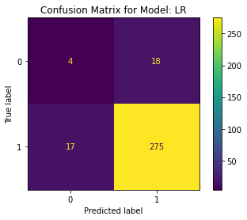

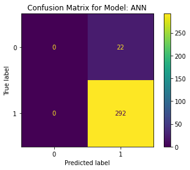

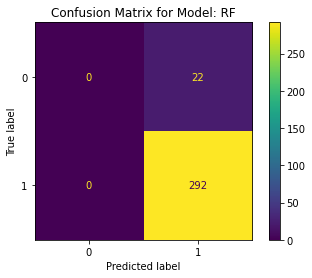

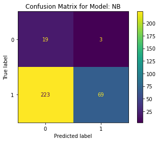

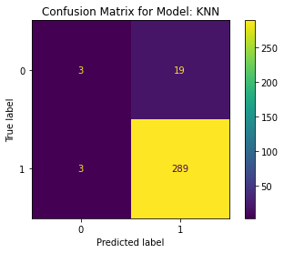

```python
from sklearn.metrics import confusion_matrix,ConfusionMatrixDisplay, accuracy_score

allac=[];
results = [];
for (name, model) in models:
    y_pred = (model.predict(X_test) > 0.5);
    cm = confusion_matrix((y_test > 0.5), y_pred);
    disp = ConfusionMatrixDisplay(confusion_matrix(y_test,(model.predict(X_test)>0.5)))
    ac = accuracy_score(y_test, y_pred);
    results.append( (name,ac,cm,disp, y_pred) );
    allac.append(ac);


for (name,ac,cm,disp, yp) in results:
    disp.plot();
    plt.title(f'Confusion Matrix for Model: {name}')
```

## Accuracy

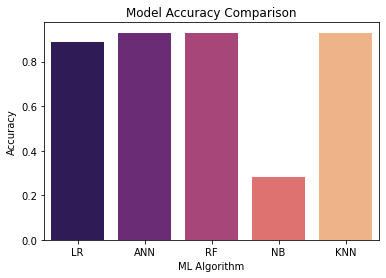

```python
names = [];
for tp in models:
    names.append(tp[0]);

sns.barplot(x=names,y=allac, palette='magma');
plt.title('Model Accuracy Comparison');
plt.ylabel('Accuracy');
plt.xlabel('ML Algorithm');
```

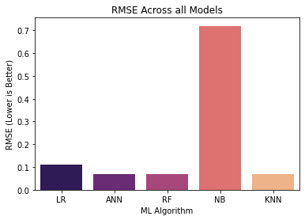

```python
from sklearn.metrics import mean_squared_error
RMSE_results=[];
for tp in results:
    RMSE_results.append(mean_squared_error(y_test, tp[-1]))
sns.barplot(x=names, y=RMSE_results, palette='magma');
plt.title('RMSE Across all Models');
plt.ylabel('RMSE (Lower is Better)');
plt.xlabel('ML Algorithm');
```

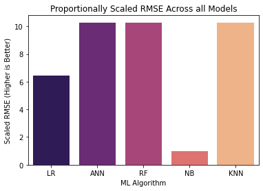

```python
sns.barplot(x=names, y=(RMSE_results/np.max(RMSE_results))**-1, palette='magma');
plt.title('Proportionally Scaled RMSE Across all Models');
plt.ylabel('Scaled RMSE (Higher is Better)');
plt.xlabel('ML Algorithm');
```

## Cross Validation

This section borrows the methodology from [Jason Brownlee at machinelearningmastery.com](https://machinelearningmastery.com/use-keras-deep-learning-models-scikit-learn-python/)

```python
#Wrap ANN for sklearn.
from tensorflow.keras.wrappers.scikit_learn import KerasClassifier
ANNmodel_wrapped = KerasClassifier(ANNmodel);


# Function to create model, required for KerasClassifier
def create_model():
    # create model
    model = tf.keras.models.Sequential();
    model.add(tf.keras.layers.Dense(n, activation='relu'));
    model.add(tf.keras.layers.Dense(n/2, activation='relu'));
    model.add(tf.keras.layers.Dense(1, activation='sigmoid'));
    # Compile model
    model.compile(loss='binary_crossentropy', optimizer='adam', metrics=['accuracy'])
    return model;

models[1] = ('ANN', KerasClassifier(build_fn=create_model, epochs=100, batch_size=150, verbose=0));



# Number of splits to make.
N = 3;

from sklearn import model_selection
from sklearn.model_selection import StratifiedKFold

CV_results = [];
scoring = 'accuracy';

for tp in models:
    kfold = StratifiedKFold(n_splits=N, shuffle=True)
    #kfold = model_selection.KFold(n_splits=N);
    CVinternal_results = model_selection.cross_val_score(tp[1], X, y, cv=kfold, scoring=scoring);
    CV_results.append((CVinternal_results));
```

```python
CV_results = pd.DataFrame(CV_results).T;
CV_results.columns = names;
```

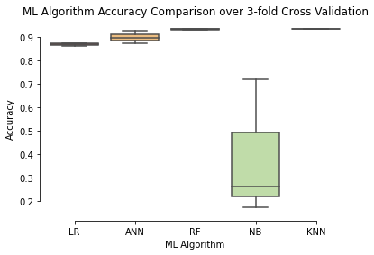

```python
ax2 = sns.boxplot(data=CV_results, palette='Spectral')
ax2.set(xlabel = "ML Algorithm",
       ylabel = 'Accuracy',
       title = f"ML Algorithm Accuracy Comparison over {N}-fold Cross Validation");
sns.despine(ax=ax2,offset=5, trim=True)
ax2.plot();
```

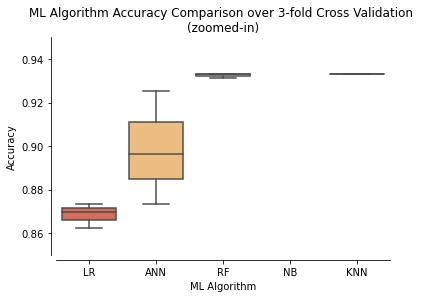

```python
ax2 = sns.boxplot(data=CV_results, palette='Spectral')
ax2.set(xlabel = "ML Algorithm",
       ylabel = 'Accuracy',
       title = f"ML Algorithm Accuracy Comparison over {N}-fold Cross Validation \n(zoomed-in)");
ax2.set(ylim=(0.85, 0.95))
sns.despine(ax=ax2,offset=5, trim=False)
ax2.plot();
```

## Performance Summary

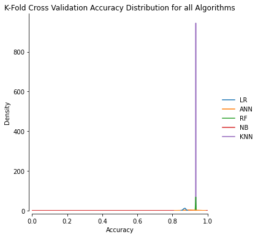

```python
g=sns.displot(data=CV_results, kind='kde');
g.despine(offset=5);
g.set_xlabels('Accuracy');
plt.title('K-Fold Cross Validation Accuracy Distribution for all Algorithms');
plt.xlim(0.0,1);
```

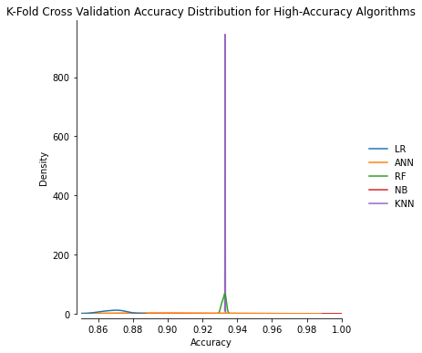

```python
g=sns.displot(data=CV_results, kind='kde');
g.despine(offset=5);
g.set_xlabels('Accuracy');
plt.title('K-Fold Cross Validation Accuracy Distribution for High-Accuracy Algorithms');
plt.xlim(0.85,1);
```

# Conclusion

Given that the computational expense of **ANN** is much greater than **RF**, and the accuracy is -on average- lower, the latter is recommended for deployment.